# Lab1Analysis

Srikari Punyamurtula

2022-11-04

## Analysis of photographs in Boulder, CO

Using social media data from Flickr and Panramio in Open Spaces and Mountain Park in Boulder, CO, we will examine what spatial variables might affect the locations at which people take photographs.

First, we will install the necessary packages.

```r
library(ggplot2)
library(sf)
library(tidyverse)
library(ggspatial)
library(viridis)
```

Next, we can install the data as a sf dataset. We will direct R to where the data is stored on my C drive.

```r
boulder <- st_read("C:/Users/srika/OneDrive/Documents/Geovisualization/Boulder_data/BoulderSocialMedia.shp")
```

Before we begin our analysis, let us visualize how the park looks in terms of elevation. We will project the data with a projection appropriate for Colorado.

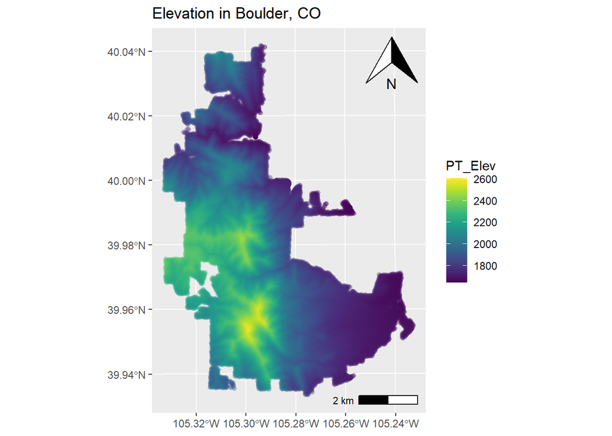

```r
boulder = st_transform(boulder, 26753)
ggplot() +
    geom_sf(data = boulder, aes(color=PT_Elev),
    fill = NA, alpha = .2) +
    scale_colour_gradientn(colours = viridis(10)) +
    annotation_scale(location = "br") +
    annotation_north_arrow(location = "tr", which_north = "true") +
    ggtitle("Elevation in Boulder, CO")
```

Let us also observe the spatial distribution of the photos being taken in the parks.

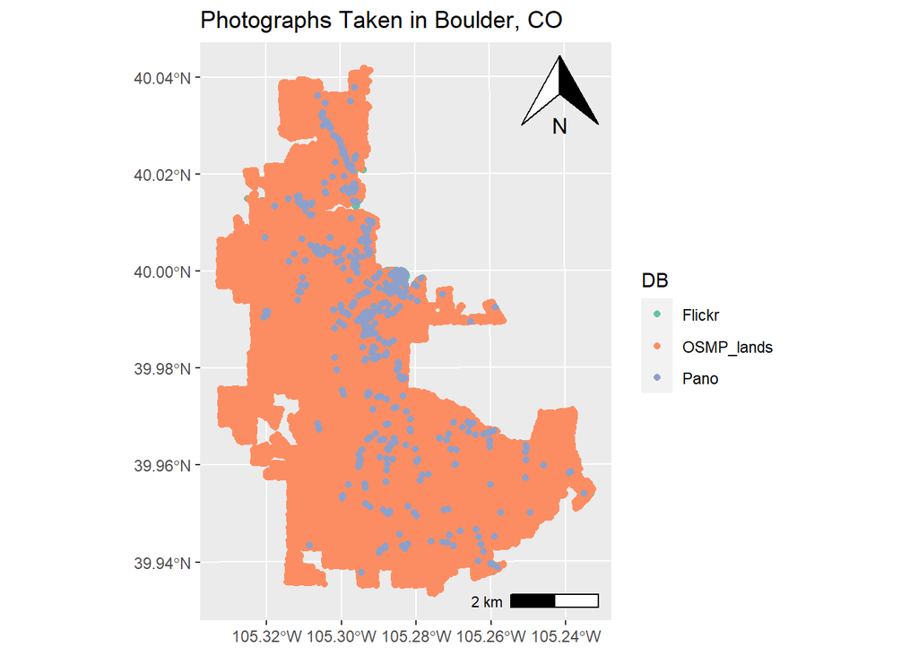

```r
p <- ggplot() +
  annotation_spatial(boulder) +
  layer_spatial(boulder, aes(col = DB))
p + scale_color_brewer(palette = "Set2") +
  annotation_scale(location = "br") +
  annotation_north_arrow(location = "tr", which_north = "true") +
  ggtitle("Photographs Taken in Boulder, CO")
```

We are interested in seeing if there is any correlation between where people are taking photographs and the distance to a natural landmark. To do this we will plot a boxplot with ggplot.

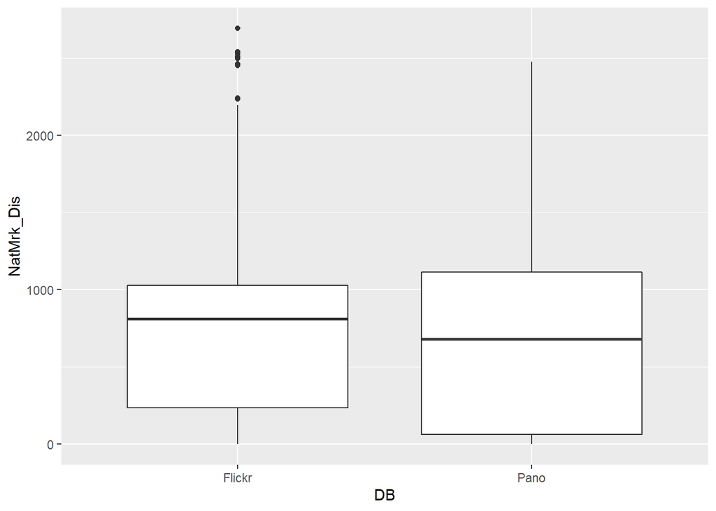

```r
 boulder %>%
  filter(DB ==  'Pano' | DB == 'Flickr') %>%
  ggplot(aes(x=DB, y=NatMrk_Dis)) +
  geom_boxplot()
```